# Pratical Machine Learning - Course Project

Author: Cleverson  
Date: May 2019

## Overview

```r
download.file(url="https://d396qusza40orc.cloudfront.net/predmachlearn/pml-training.csv",
              destfile="pml-training.csv")
download.file(url="https://d396qusza40orc.cloudfront.net/predmachlearn/pml-testing.csv",
              destfile="pml-testing.csv")
```

Loading the libraries:

```r
library(caret)
library(randomForest)
```

Loading the data sets:

```r
data_training<-read.csv("pml-training.csv")
validation<-read.csv("pml-testing.csv")
```

### Slicing the data

70% of the data are used to train, the other 30% are used to test.

```r
inTrain<-createDataPartition(y=data_training$classe,p=0.7,list=FALSE)
training<-data_training[inTrain,]
testing<-data_training[-inTrain,]
```

```r
dim(training)
```

```
## [1] 13737   160
```

### Removing variables

Apart from the outcome (**classe** data set variable), there are a total of 159 variables (potential predictors). To ease the processing, variables with NA values are removed, a total of 93 variables remains:

```r
training<-training[,colSums(is.na(training))==0]
```

```r
dim(training)
```

```
## [1] 13737    93
```

Number of variables can still be decreased, a second step is to remove the ones with very few unique values, that means removing the ones with low variance. A total of 59 variables remains:

```r
nzv<-nearZeroVar(training)
training<-training[,-nzv]
```

```r
dim(training)
```

```
## [1] 13737    59
```

Looking into the data set, there are some variables that are used as identification and index, that means they didn’t come from the accelorometers and don’t have a role to play on the prediction part. These variables are removed, a total of 53 variables remains:

```r
training<-training[,c(7:59)]
```

```r
dim(training)
```

```
## [1] 13737    53
```

This training data set version is the one used to train, test and validate.

## Training

To ensure the results are repetable:

```r
set.seed(1245)
```

For non-linear settings, prediction with decision trees has better performance compared to linear regression models. 3 fitting models are created based on training data set:

### 1. Regression Trees model

Starting by the basic tree model:

```r
mod.fit.rpart<-train(classe~., data=training, method="rpart")
```

### 2. Random Forests model

This model bootstrap samples, that means data set is resampled and for each of the samples, a regression tree is created leading to a large number of trees in the end. That improves accuracy, however it is very slow and there is a risk of overfitting.

```r
mod.fit.rf<-train(classe~., data=training, method="rf", prox=TRUE)
```

### 3. Gradient Boosting Machine model

The idea behind boosting is to take weak predictors and add them up to take advantage of their strength, it was used here with trees (**gbm**).

```r
mod.fit.gbm<-train(classe~., method="gbm", data=training, verbose=FALSE)
```

## Predicting

Each fitting model was used to predict on testing data set.

```r
pred.rpart<-predict(mod.fit.rpart,testing)
pred.rf<-predict(mod.fit.rf,testing)
pred.gbm<-predict(mod.fit.gbm,testing)
```

### Accuracy

Accuracy of these 3 models were calculated through confusion matrix, which is used to describe the performance of a model on a test data set.  
Tree model accuracy:

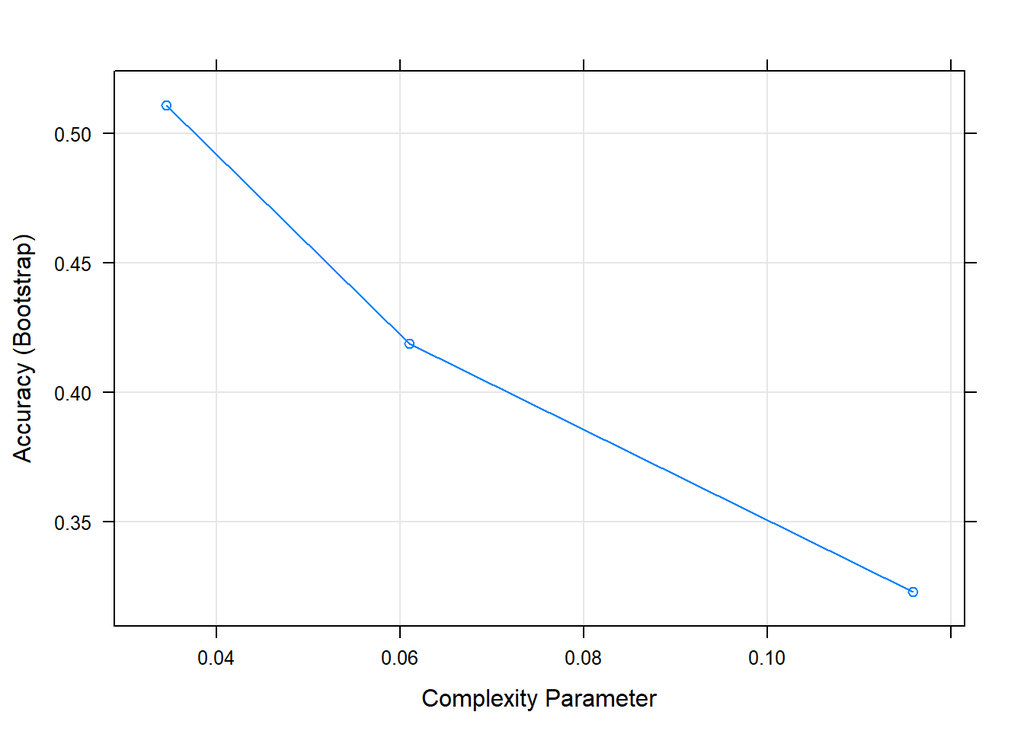

```r
plot(mod.fit.rpart)
```

```r
cMatrix_rpart<-confusionMatrix(pred.rpart,testing$classe)
```

```r
cMatrix_rpart$table
```

```
##           Reference
## Prediction    A    B    C    D    E
##          A 1522  503  482  437  157
##          B   28  374   36  168  149
##          C  123  262  508  359  297
##          D    0    0    0    0    0
##          E    1    0    0    0  479
```

```r
cMatrix_rpart$overall[1]
```

```
##  Accuracy
## 0.4898895
```

Random Forest model accuracy:

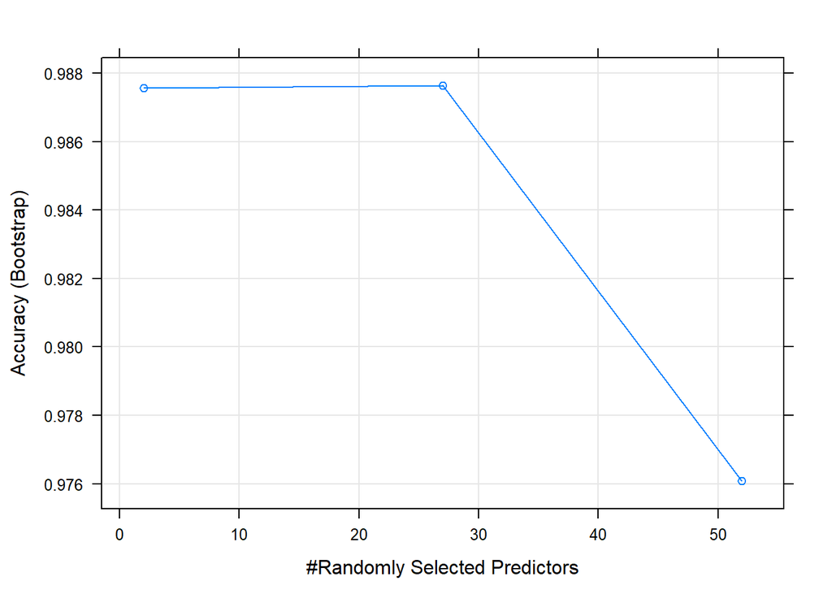

```r
plot(mod.fit.rf)
```

```r
cMatrix_rf<-confusionMatrix(pred.rf,testing$classe)
```

```r
cMatrix_rf$table
```

```
##           Reference
## Prediction    A    B    C    D    E
##          A 1674    7    0    0    0
##          B    0 1130    7    1    1
##          C    0    1 1014    7    2
##          D    0    1    5  956    1
##          E    0    0    0    0 1078
```

```r
cMatrix_rf$overall[1]
```

```
##  Accuracy
## 0.9943925
```

Gradient Boosting Machine model accuracy:

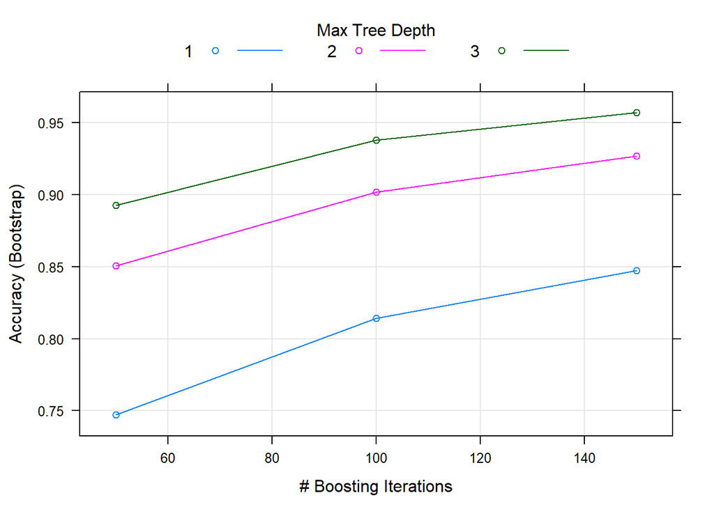

```r
plot(mod.fit.gbm)
```

```r
cMatrix_gbm<-confusionMatrix(pred.gbm,testing$classe)
```

```r
cMatrix_gbm$table
```

```
##           Reference
## Prediction    A    B    C    D    E
##          A 1659   36    0    1    0
##          B   11 1071   29    6   12
##          C    3   30  976   39    8
##          D    1    2   17  911   14
##          E    0    0    4    7 1048
```

```r
cMatrix_gbm$overall[1]
```

```
##  Accuracy
## 0.9626168
```

The most precise model is the Random Forest, accuracy of 0.99. So, no combination of prediction models is necessary. This is the model used for the validation step.

## Validating

A set of 20 observations (validation data set) were used to validate the prediction model.

```r
pred.validation<-predict(mod.fit.rf,validation)
pred.results <- data.frame(problem_id=validation$problem_id,predicted=pred.validation)
```

These are the results:

```r
print(pred.results)
```

```
##    problem_id predicted
## 1           1         B
## 2           2         A
## 3           3         B
## 4           4         A
## 5           5         A
## 6           6         E
## 7           7         D
## 8           8         B
## 9           9         A
## 10         10         A
## 11         11         B
## 12         12         C
## 13         13         B
## 14         14         A
## 15         15         E
## 16         16         E
## 17         17         A
## 18         18         B
## 19         19         B
## 20         20         B
```